# Data viz basics with R and ggplot2

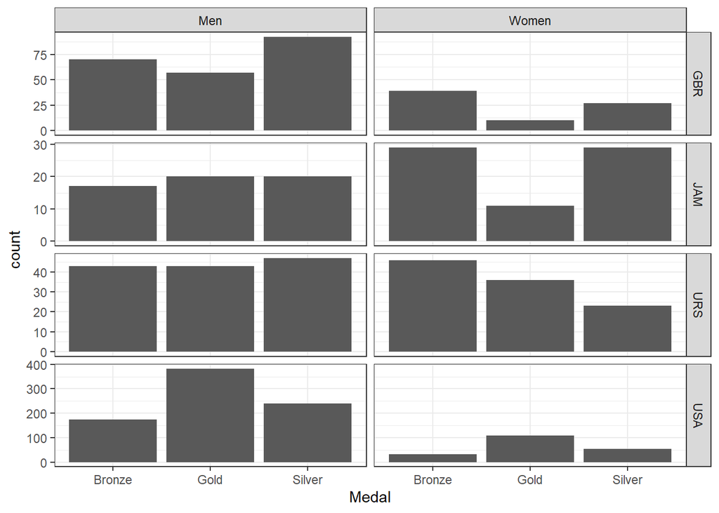

```r
ggplot(olympics_best, aes(x = Medal)) +
  geom_bar(stat = 'count') +
  facet_grid(Country ~ Gender, scales = 'free_y')
```

Let’s improve the appearance of this plot. First, you can see that the order of the medals is alphabetical (Bronze, Gold, Silver) instead of the logical Bronze, Silver, Gold. The best way to change this is by changing the underlying data before you create the plot. We will change the `Medal` column to a factor and specify the order of the factor levels. Then, when the plot is created, the bars will appear in that order.

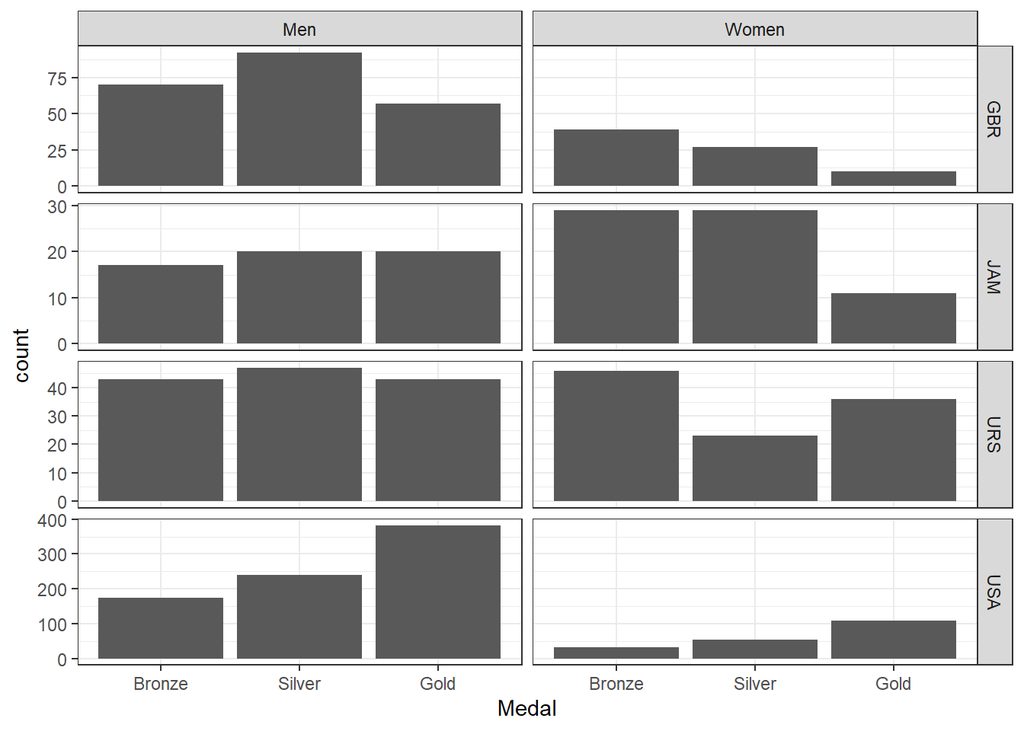

```r
olympics_best$Medal <- factor(olympics_best$Medal, levels = c('Bronze', 'Silver', 'Gold'))

ggplot(olympics_best, aes(x = Medal)) +
  geom_bar(stat = 'count') +
  facet_grid(Country ~ Gender, scales = 'free_y')
```

Now I’ll add some theme elements, a title and subtitle, and a custom fill scale to fill each medal bar with the appropriate color.

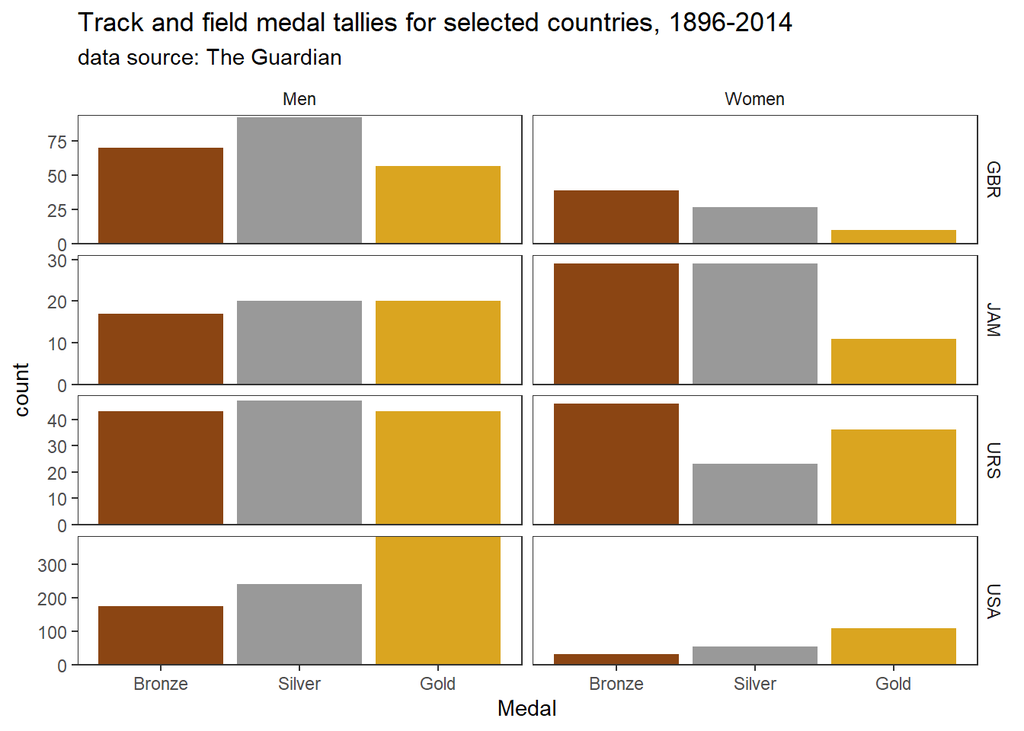

```r
ggplot(olympics_best, aes(x = Medal, fill = Medal)) +
  geom_bar(stat = 'count') +
  facet_grid(Country ~ Gender, scales = 'free_y') +
  ggtitle('Track and field medal tallies for selected countries, 1896-2014', subtitle = 'data source: The Guardian') +
  scale_y_continuous(expand = expansion(add = c(0, 2))) +
  scale_fill_manual(values = c(Bronze = 'chocolate4', Silver = 'gray60', Gold = 'goldenrod')) +
  theme(legend.position = 'none',
        strip.background = element_blank(),
        panel.grid = element_blank())
```

> Notice I had to add `fill = Medal` to the `aes()` mapping so that the custom scale I made would be applied to fill the bars by color. The `Medal` variable is mapped to both the `x` and `fill` graphical elements. Strictly speaking this is redundant but it makes the plot look cooler!

## Writing your ggplot to a file

You can use the `ggsave()` function to write your plot to a file. `ggsave()` will automatically determine the file type based on the extension on the file name. It will also set the size and resolution of the image by default. (Note this example assumes there is a folder called `plots` in your home directory.)

```r
# Not run
ggsave('~/plots/sugar_histogram.png', sugar_hist)
```

We can specify the resolution in dpi (dots per inch) and the size of the image. By default the units are inches but we can specify other units if needed.

```r
# Not run
ggsave('~/plots/sugar_histogram.png', sugar_hist, dpi = 400, height = 4, width = 4)
ggsave('~/plots/sugar_histogram.png', sugar_hist, dpi = 400, height = 9, width = 9, units = 'cm')
```

We can use other file types such as PDF (vector graphics, so you don’t supply a resolution)

```r
# Not run
ggsave('~/plots/sugar_histogram.pdf', sugar_hist, height = 4, width = 4)
```

If you don’t specify a plot object, it will write the last ggplot you plotted in the plotting window to the file. (This will be the last Olympics plot we made).

```r
ggsave('~/plots/my_plot.pdf', height = 4, width = 4)
```

## Going further

We’ve only scratched the surface of **ggplot2** in this lesson.

The **ggplot2** package itself doesn’t support every possible kind of data visualization. But because R packages are all open-source and anyone can contribute his or her own package, there is a very diverse “ecosystem” of extension packages people have written as add-ons to **ggplot2**. We don’t have time to get into any of them in detail right now. Here are a few examples of extension packages and some bits of code showing them in action. I encourage you to explore them more!

### ggthemes

This is a package that includes a bunch of themes you can add to your plot to spiff up its appearance. Here I use it to draw our sugar histogram plot in the style of *The Economist*, FiveThirtyEight.com, and the personal style of data visualization expert Edward Tufte.

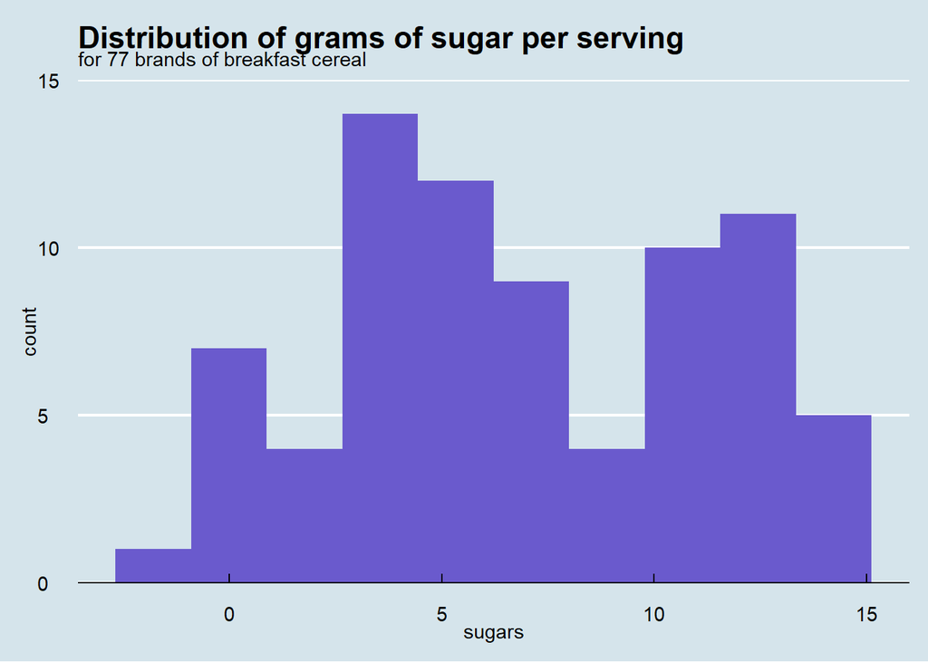

```r
library(ggthemes)

sugar_hist + theme_economist()
```

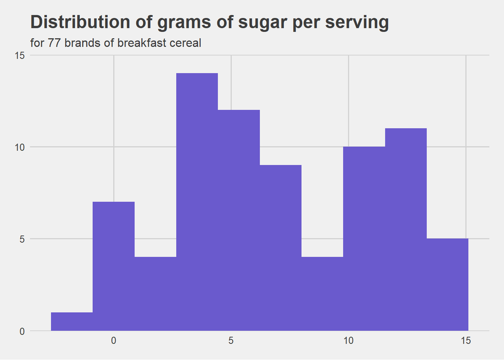

```r
sugar_hist + theme_fivethirtyeight()
```

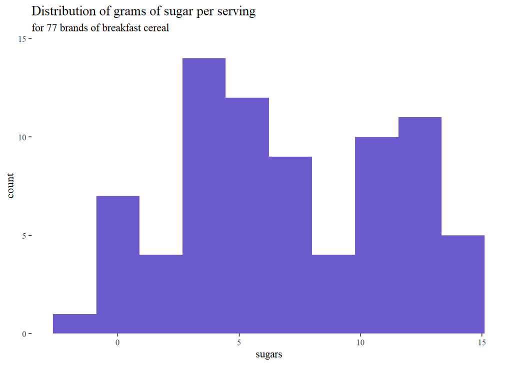

```r
sugar_hist + theme_tufte()
```

### gghighlight

This package has functions that allow us to highlight outliers or other specific bits of our data automatically. For example let’s go back to our happiness versus GDP plot and highlight the “happiest” and “saddest” countries, complete with labels.

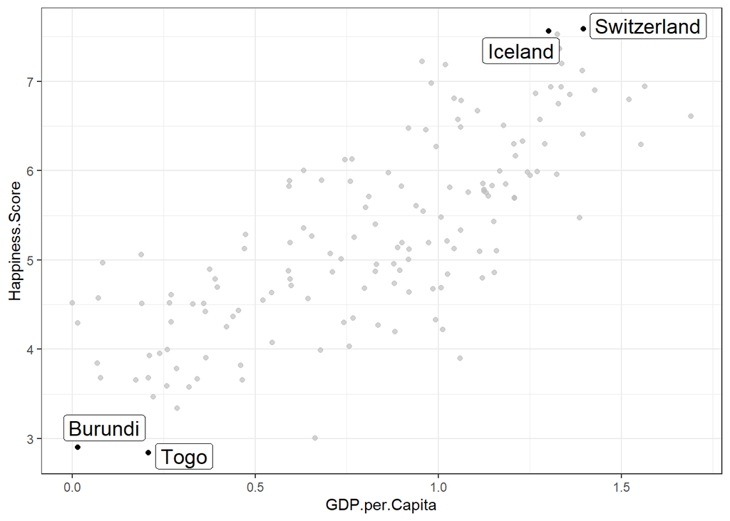

```r
library(gghighlight)

ggplot(data = WHR, aes(x = GDP.per.Capita, y = Happiness.Score)) +
  geom_point() +
  gghighlight(Happiness.Score < 3 | Happiness.Score > 7.55, label_key = Country, label_params = list(size = 5))
```

### ggpubr

This package tries to streamline the process of formatting plots to make them publication-ready with simplified functions. For example, we can make a pretty boxplot of happiness score by continent with the raw data added as jittered points, without having to specify all the `geom`s. We can even add specific “significant” comparisons to the plot with connecting lines. Let’s assume in this case that the Americas and Europe had significantly greater happiness score than Africa, but no other pairwise comparisons showed significant differences.

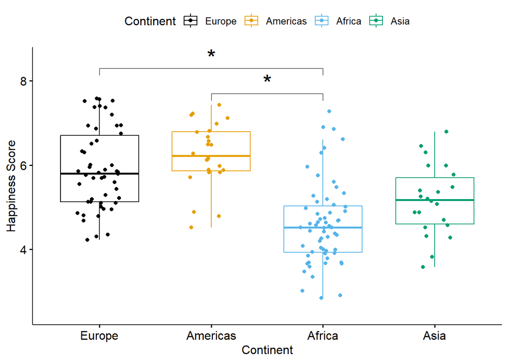

```r
library(ggpubr)

ggboxplot(data = WHR, x = 'Continent', y = 'Happiness.Score', color = 'Continent', add = 'jitter',
          palette = unname(palette.colors(4)),
          ylab = 'Happiness Score', ylim = c(2.5, 8.5)) +
  geom_bracket(xmin = 'Europe', xmax = 'Africa', label = '*', y.position = 8.3, label.size = 8) +
  geom_bracket(xmin = 'Americas', xmax = 'Africa', label = '*', y.position = 7.7, label.size = 8)
```

### The list goes on …

Check out the official [ggplot2 extensions page](https://exts.ggplot2.tidyverse.org/) to browse a full list.

# Conclusion

What did we just learn? Let’s revisit the learning objectives!

- what the “grammar of graphics” is and how **ggplot2** uses it
- how to map a variable in a data frame to a graphical element in a plot using `aes`
- how to use different `geom`s to make scatterplots, boxplots, histograms, density plots, and barplots
- how to add trendlines to a plot
- how to compute summary statistics and plot them with `stat` functions
- how to make plots for different subsets of your data using `facet`s
- how to change the style and appearance of your plots

Take the time to pat yourself on the back for making it this far. Now get out there and visualize some data!

## Further reading

- [ggplot2 homepage](https://ggplot2.tidyverse.org/)
- [ggplot2: Elegant Graphics for Data Analysis](https://ggplot2-book.org/): This is the “official” book on **ggplot2**, written by the package developers. It explains the underlying theory of grammar of graphics and thoroughly documents all the features.
- [R Graph Gallery ggplot2 page](https://r-graph-gallery.com/ggplot2-package.html): huge collection of **ggplot2** examples with the code to produce each one
- [ggplot2 chapter in the book *R for Data Science*](https://r4ds.had.co.nz/graphics-for-communication.html)

# Exercises

The example datasets we worked with in this lesson have a lot more columns that we haven’t worked with yet. In these exercises, we will explore the `cereal` dataset further. The dataset has a column called `rating` which is a score on a scale from 0-100 representing how healthy the cereal is (All-Bran with Extra Fiber is the highest at 94 and Cap’n Crunch the lowest at 18).

### Exercise 1

#### 1a

Make a density plot showing the distribution of ratings across all 77 cereals.

#### 1b

Change the density plot from the previous exercise to a histogram.

#### 1c

Fill the histogram bars with the color of your choice. Change the y-axis of the histogram so that there is no gap between the bars and the bottom of the plot.

- *Hint*: Use `scale_y_continuous(expand = expansion(add = ...))`.

### Exercise 2

#### 2a

Make a boxplot grouped by the column `manufacturer` to show which manufacturers produce healthier cereals.

#### 2b

Fill the boxplots with the color of your choice. Make the outliers into hollow circles.

- *Hint*: Use `outlier.shape = 1`.

### Exercise 3

#### 3a

- Make a scatterplot with `sugars` on the x-axis and `rating` on the y-axis to look at whether healthier-rated cereals have more or less sugar per serving.

#### 3b

Include a linear trend on the scatterplot with standard error.

- *Hint*: Use `geom_smooth()` and modify the argument `method`.

#### 3c

Change the y-axis range on the scatterplot so that it goes from 0 to 100, with labels at 0, 25, 50, 75, and 100.

- *Hint*: Use `scale_y_continuous()`, and modify the arguments `limits` and `breaks`.

#### 3d

Split the scatterplot with trendline up by the `type` column to produce one scatterplot for cold cereals and one scatterplot for hot cereals.

- *Hint*: Use `facet_wrap(~ ...)`.

**Click here for answers**